# Homework #4

3/1/2018

## Chick weights

The `ChickWeight` data set is part of the base package `datasets`. See `?ChickWeight` for details on the data. For all of the questions use `dplyr` functions whenever possible.

```r
library(tidyverse)
```

```r
library(ggplot2)
library(knitr)
data(ChickWeight)
```

1. Download the RMarkdown file with these homework instructions to use as a template for your work. Make sure to replace “Your Name” in the YAML with your name.
2. Get a frequency breakdown of the number of chicks, their average weight and the standard deviation of the weights in each of the diets at the start of the study.

First, Get the data points collected on day 0 (birth)

```r
start_data <- filter(ChickWeight, Time == 0)
```

Then, average the weight column.

```r
average_weight <- mean(start_data$weight)
```

The average weight chick is 41.06 grams

Now, group the data by diet type.

```r
start_data %>%
  group_by(Diet) -> start_weight_by_diet
```

Next, the mean and stdev are computed for each diet type.

```r
start_weight_by_diet %>%
  summarize(Mean = mean(weight,
                        na.rm=TRUE),
            sd=sd(weight)) ->
  start_weights_mean_stdev
print(start_weights_mean_stdev)
```

```
## # A tibble: 4 x 3
##   Diet   Mean    sd
##   <fct> <dbl> <dbl>
## 1 1      41.4 0.995
## 2 2      40.7 1.49
## 3 3      40.8 1.03
## 4 4      41.0 1.05
```

0.5 pts of extra credit: construct a ggplot that shows average weights by diet with an interval (shown as a line) of +- the standard deviation around the averages.

Next, we take the dataframe with diets, weight averages, and standard deviations, and plot it.

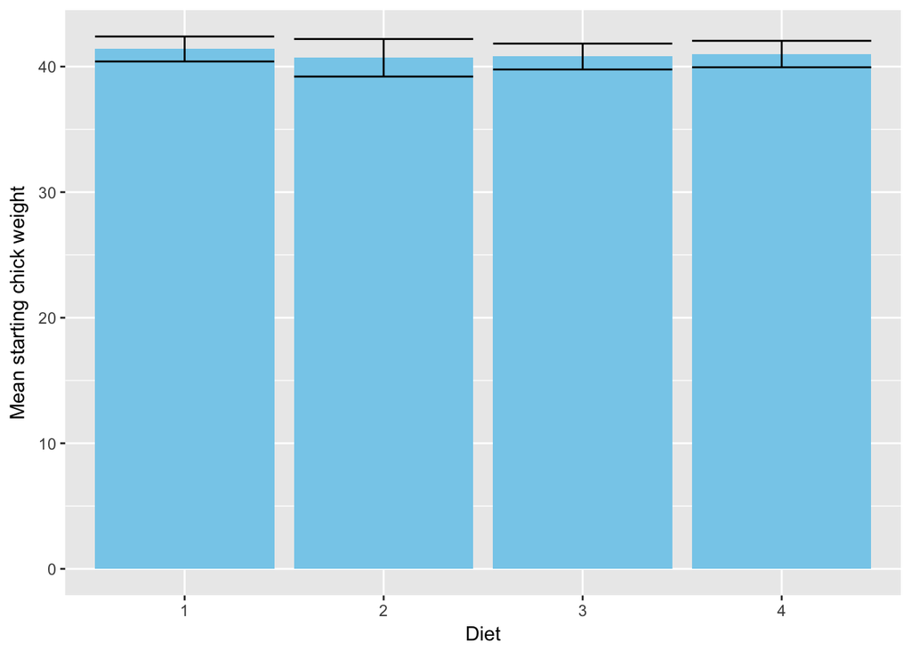

```r
start_weights_mean_stdev %>%
  ggplot(aes(x=Diet, y=Mean)) +
  geom_col(fill="skyblue") +
  geom_errorbar(aes(ymin=Mean-sd, ymax=Mean+sd)) +
  ylab("Mean starting chick weight")
```

3. Each chick should have twelve weight measurements. Use the dplyr package to identify how many chicks have a complete set of weight measurements and how many measurements there are in the incomplete cases. Extract a subset of the data for all chicks with complete information and name the data set `complete`. (Hint: you might want to use mutate to introduce a helper variable consisting of the number of observations)

First, get a count of the number of data entries for each chick.

A complete dataset has 12 entries in it and no more.

```r
chick_data_entries <- count(ChickWeight, Chick)
chick_data_entries
```

```
## # A tibble: 50 x 2
##    Chick     n
##    <ord> <int>
##  1 18        2
##  2 16        7
##  3 15        8
##  4 13       12
##  5 9        12
##  6 20       12
##  7 10       12
##  8 8        11
##  9 17       12
## 10 19       12
## # ... with 40 more rows
```

Next, get the list of chick entries that are not equal to 12

```r
incomplete_chick_sets <-chick_data_entries %>% filter(n != 12)
incomplete_chick_sets
```

```
## # A tibble: 5 x 2
##   Chick     n
##   <ord> <int>
## 1 18        2
## 2 16        7
## 3 15        8
## 4 8        11
## 5 44       10
```

Now, filter out any chicks that have incomplete datasets.

```r
ChickWeight %>%
  filter(!(Chick %in% incomplete_chick_sets$Chick)) ->
  complete
count(complete, Chick)
```

```
## # A tibble: 45 x 2
##    Chick     n
##    <ord> <int>
##  1 13       12
##  2 9        12
##  3 20       12
##  4 10       12
##  5 17       12
##  6 19       12
##  7 4        12
##  8 6        12
##  9 11       12
## 10 3        12
## # ... with 35 more rows
```

4. In the complete data set introduce a new variable that measures the current weight difference compared to day 0. Name this variable `weightgain`.

Fill in the starting weight for each chick as a column. Use the starting weight to compute the weight gained.

```r
complete %>%
  group_by(Chick) %>%
  mutate(start_weight = weight[1]) %>%
  mutate(weightgain = weight - start_weight) -> complete_weight_gain
```

Drop the temporary starting weight column, keep the new `weightgain` column.

```r
complete_weight_gain %>%
  select(-start_weight) -> complete_weight_gain

head(complete_weight_gain)
```

```
## # A tibble: 6 x 5
## # Groups:   Chick [1]
##   weight  Time Chick Diet  weightgain
##    <dbl> <dbl> <ord> <fct>      <dbl>
## 1   42.0  0    1     1           0
## 2   51.0  2.00 1     1           9.00
## 3   59.0  4.00 1     1          17.0
## 4   64.0  6.00 1     1          22.0
## 5   76.0  8.00 1     1          34.0
## 6   93.0 10.0  1     1          51.0
```

5. Use ggplot2 to create side-by-side boxplots of `weightgain` by `Diet` for day 21. Describe the relationship in 2-3 sentences. Change the order of the categories in the Diet variable such that the boxplots are ordered by median `weightgain`.

First, we only care about the weight gain for the last day.

Filter out everything except day 21.

```r
final_gains <- filter(complete_weight_gain, Time == 21)
```

Finally, plot boxplots of weight gains grouped by diet.

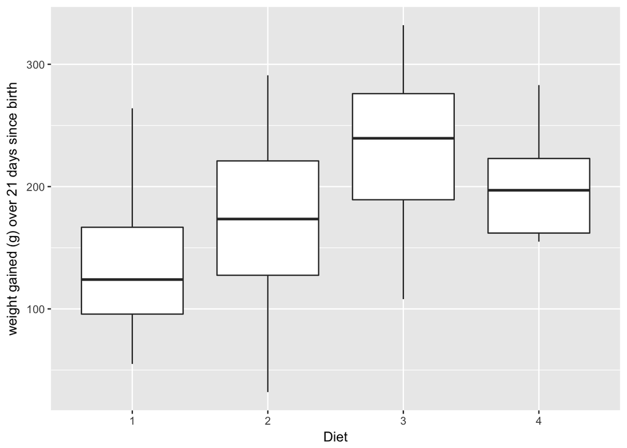

[output not shown]

```r
final_gains %>% ggplot(aes(x=Diet, y=weightgain)) +
  geom_boxplot() +
  ylab("weight gained (g) over 21 days since birth")
```

Diet 1 has the lowest median weight gain.

Diet 3 has the highest weight gain over 21 days.

Diet 4 has the lowest standard deviation.

Note: your submission is supposed to be fully reproducible, i.e. the TA and I will ‘knit’ your submission in RStudio.

For the submission: submit your solution in an R Markdown file and (just for insurance) submit the corresponding html (or Word) file with it.